# Upchurch Nonparametric HW #6

Allison Upchurch

4/11/2020

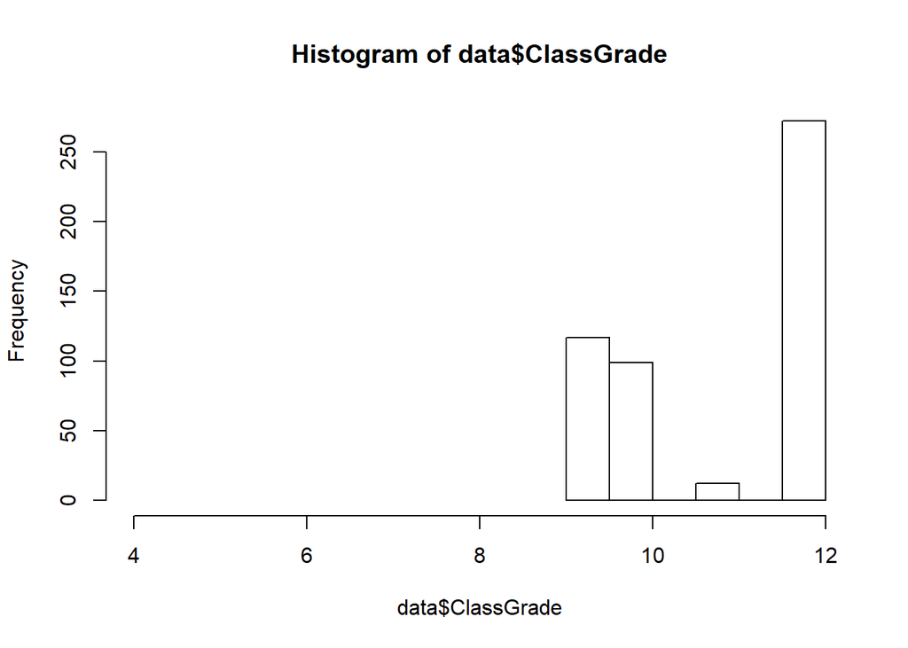

```r
data = read.csv('C:\\Users\\allis\\Downloads\\ill_school_data.csv')
hist(data$ClassGrade,breaks = 9, xlim=c(4,12))
```

```r
summary(data$Ageyears)
```

```
##    Min. 1st Qu.  Median    Mean 3rd Qu.    Max.    NA's
##   12.00   15.00   17.00   16.36   17.00   99.00       4
```

This data set contains a variety of self-reported measurements about US schoolchildren such as their age, favorite subject, time spent online, etc. One interesting aspect of this dataset is that the lowest grade level is 9th grade, but the ages range from 12 to 99 years old, so clearly there are some errors in the age column.

```r
data.1 = data[c(7,29)]
nrow(data.1)
```

```
## [1] 500
```

```r
data.2 = data.1[!(data.1$Handed == ""), ]
nrow(data.2)
```

```
## [1] 488
```

```r
data.3 = data.2[!(data.2$Favorite_Season == ""),]
nrow(data.3)
```

```
## [1] 449
```

```r
nrow(data.3)/500
```

```
## [1] 0.898
```

Removing all blanks is a reasonable way to deal with missing data in this situation, because 89.8% of the observations are still remaining.

```r
data.3$Handed = factor(data.3$Handed)
data.3$Favorite_Season = factor(data.3$Favorite_Season)
tab = table(data.3$Handed, data.3$Favorite_Season)
print(tab)
```

```
##
##                Fall Spring Summer Winter
##   Ambidextrous    7      2      4      3
##   Left-Handed    14      8     17      5
##   Right-Handed  157     47    146     39
```

```r
chisq.test(tab)
```

```
##
##  Pearson's Chi-squared test
##
## data:  tab
## X-squared = 3.7881, df = 6, p-value = 0.7053
```

I used the chi-squared test becuase the data isn’t paired and the outcome is a qualitative response, so this was the most appropriate non-parametric test. Based on the p-value of 0.7053, we fail to reject the null hypothesis that handedness is independent of favorite season.

```r
library(mice)
dat = data[c(4,6,8,9,10)]
dat = dat[-c(7),]
dat[dat == ""] = NA
dat.2 = mice(dat, m=5, method = 'cart', seed = 123)
fit = with(data = dat.2, exp = lm(as.numeric(Height_cm) ~ as.numeric(Armspan_cm)))
summary(pool(fit))
```

```
##                         estimate  std.error statistic       df p.value
## (Intercept)            33.746029 2.68487007  12.56896 154.2321       0
## as.numeric(Armspan_cm)  0.452267 0.04051924  11.16178 117.7482       0
```

The final estimate for the Armspan predictor is 0.4523 with a standard error of 0.0405, and the estimate for the intercept is 33.746 with a standard error of 2.685

```r
library(mice)
dat$Height_cm = as.numeric(dat$Height_cm)
dat$Footlength_cm = as.numeric(dat$Footlength_cm)
dat$Armspan_cm = as.numeric(dat$Armspan_cm)
dat.3 = mice(dat, m=5, method = 'rf', seed = 123)
fit = with(data = dat.3, exp = lm(as.numeric(Height_cm) ~ as.numeric(Armspan_cm)))
summary(pool(fit))
```

```
##                          estimate  std.error statistic       df p.value
## (Intercept)            33.0933185 2.66509753  12.41730 156.5909       0
## as.numeric(Armspan_cm)  0.4634523 0.03845563  12.05161 290.7414       0
```

The estimate for the intercept is 33.093 with a standard error of 2.666, and the estimate for the Armspan is 0.463 with a standard error 0.0385